# Robbery in Central San Francisco

Dan Kirlin

December 29, 2015

In this project, we will be examining Crime in San Francisco using the `R` programming language and `ggplot2` package. Let’s begin by loading the ggplot2 package, dplyr (data manipulation), and the provided data.

```r
require(ggplot2);require(dplyr);
sanfrancisco <- read.csv("sanfrancisco_incidents_summer_2014.csv")
```

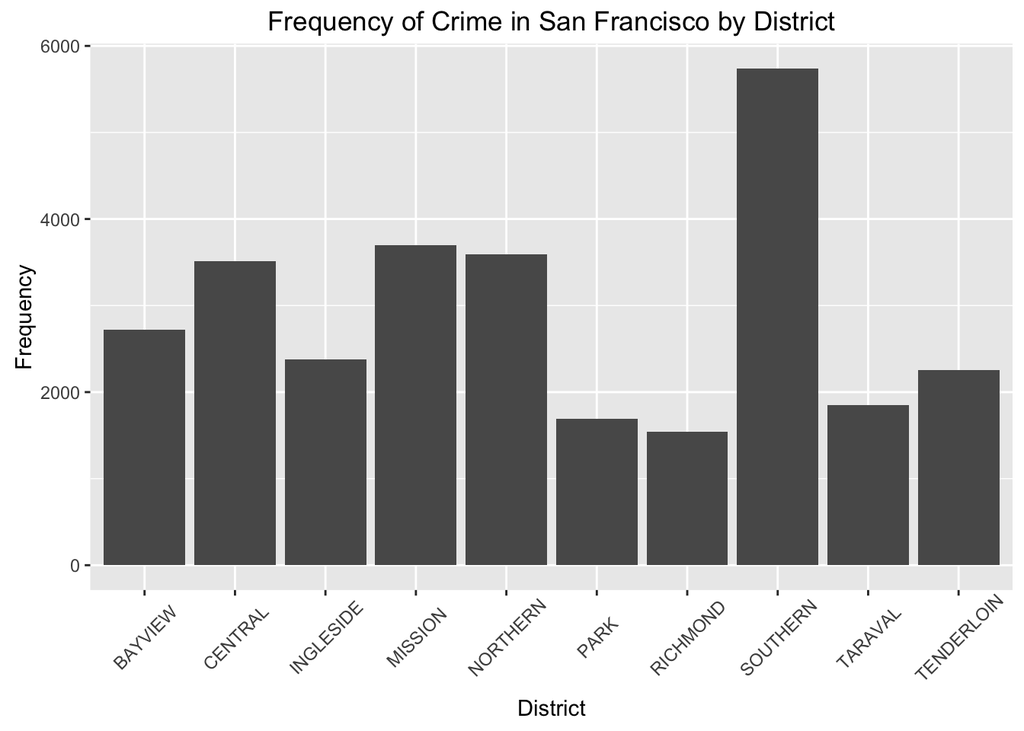

```r
plot_neighborhood <- ggplot(sanfrancisco, aes(x = PdDistrict))
plot_neighborhood <- plot_neighborhood + geom_bar()
plot_neighborhood <- plot_neighborhood + labs(y = "Frequency", x = "District")
plot_neighborhood <- plot_neighborhood + theme(axis.text.x=element_text(angle=45,vjust=.6))
plot_neighborhood <- plot_neighborhood + ggtitle("Frequency of Crime in San Francisco by District")
plot_neighborhood
```

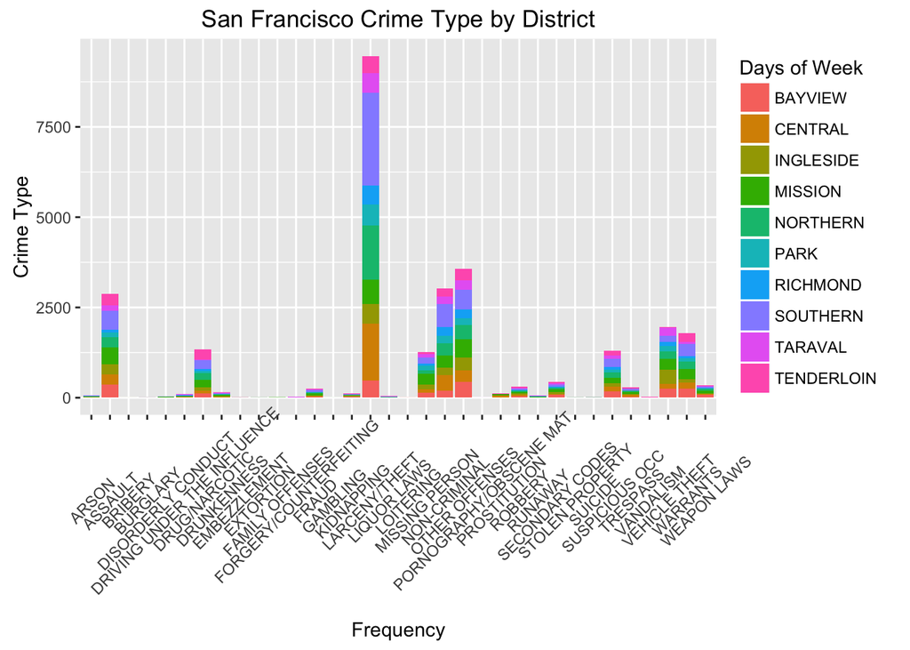

```r
plot <- ggplot(sanfrancisco, aes(x = Category, fill=PdDistrict))
plot <- plot + theme(axis.text.x=element_text(angle=45,vjust=.6))
plot <- plot + geom_bar()
plot <- plot + xlab("Frequency")
plot <- plot + ylab("Crime Type")
plot <- plot + ggtitle("San Francisco Crime Type by District")
plot <- plot + scale_fill_discrete(name = "Days of Week")
plot
```

In Central San Francisco we can see that Larceny and Theft is even more strongly represented in this district (nearly quadruple the next crime type of “non-criminal”).

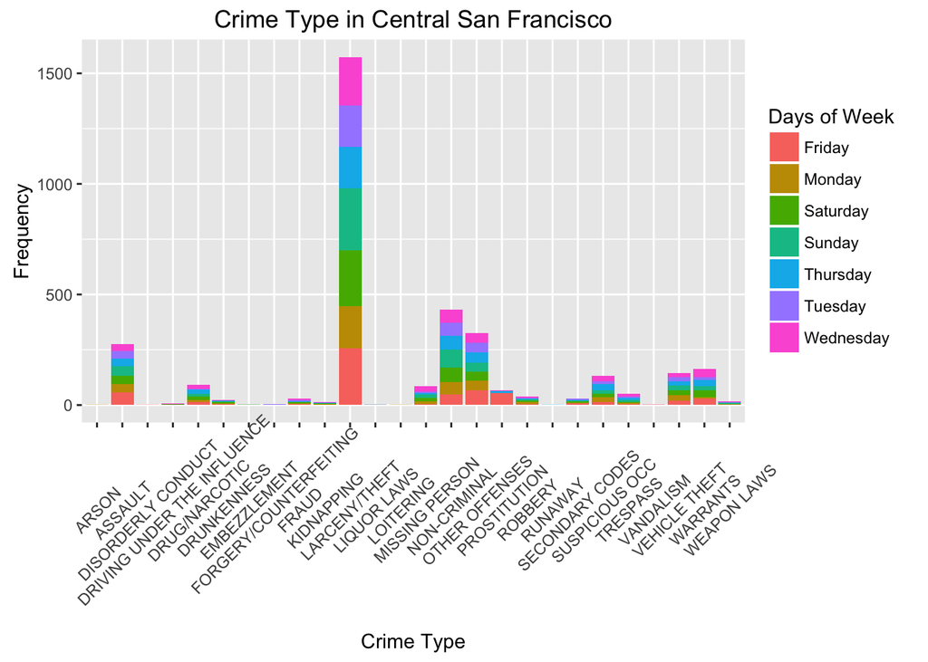

```r
sanfrancisco_center <- filter(sanfrancisco, PdDistrict=="CENTRAL")
plot_incidents <- ggplot(sanfrancisco_center, aes(x=Category, fill=DayOfWeek))
plot_incidents <- plot_incidents + geom_bar()
plot_incidents <- plot_incidents + theme(axis.text.x=element_text(angle=45,vjust=.6))
plot_incidents <- plot_incidents + labs(x = "Crime Type", y = "Frequency")
plot_incidents <- plot_incidents + ggtitle("Crime Type in Central San Francisco")
plot_incidents <- plot_incidents + scale_fill_discrete(name = "Days of Week")
plot_incidents
```

From a purely Robbery/Theft perspective we see that central is only second to that of southern. Which when compares to only 4th overall for crime of the districts, is a significant jump.

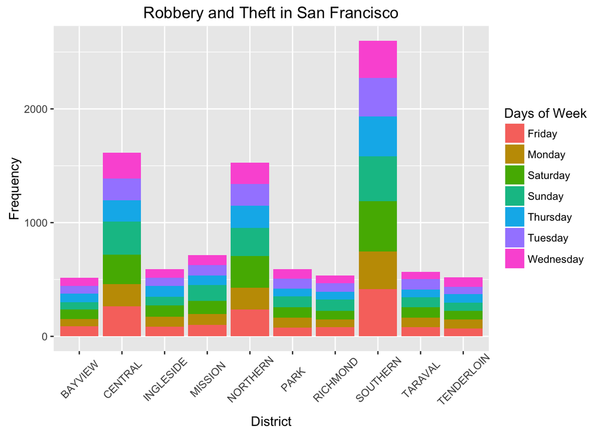

```r
sanfrancisco_theft <- filter(sanfrancisco, Category == 'ROBBERY' | Category == 'LARCENY/THEFT')
plot_theft <- ggplot(sanfrancisco_theft, aes(x=PdDistrict, fill=DayOfWeek))
plot_theft <- plot_theft + geom_bar()
plot_theft <- plot_theft + ggtitle("Robbery and Theft in San Francisco")
plot_theft <- plot_theft + labs(x = "District", y = "Frequency")
plot_theft <- plot_theft + scale_fill_discrete(name = "Days of Week")
plot_theft <- plot_theft + theme(axis.text.x=element_text(angle=45,vjust=.6))
plot_theft
```